# Statistical inference with the GSS data

## Setup

### Load packages

```r
library(ggplot2)
library(dplyr)
library(statsr)
```

### Load data

Make sure your data and R Markdown files are in the same directory. When loaded your data file will be called `gss`. Delete this note when before you submit your work.

```r
load("gss.RData")
```

## Part 1: Data

GSS questions cover a diverse range of issues including national spending priorities, marijuana use, crime and punishment, race relations, quality of life, confidence in institutions, and sexual behavior. It is an observational study where random interviews for non-institutionalized english and spanish speaking people aged 18 and over, using probability sampling were made. Additionally, recently sub-sampling among non-respondents was also utilized. This means that this data can be generalized to the entire population but causality cannot be determined as there was no random assignment. * * *

## Part 2: Research question

```r
# exploring the data
dim(gss)
```

```
## [1] 57061   114
```

```r
head(gss)
```

```
##   caseid year age    sex  race hispanic uscitzn educ paeduc maeduc speduc
## 1      1 1972  23 Female White     <NA>    <NA>   16     10     NA     NA
## 2      2 1972  70   Male White     <NA>    <NA>   10      8      8     12
## 3      3 1972  48 Female White     <NA>    <NA>   12      8      8     11
## 4      4 1972  27 Female White     <NA>    <NA>   17     16     12     20
## 5      5 1972  61 Female White     <NA>    <NA>   12      8      8     12
## 6      6 1972  26   Male White     <NA>    <NA>   14     18     19     NA
##           degree vetyears sei          wrkstat       wrkslf       marital
## 1       Bachelor     <NA>  NA Working Fulltime Someone Else Never Married
## 2 Lt High School     <NA>  NA          Retired Someone Else       Married
## 3    High School     <NA>  NA Working Parttime Someone Else       Married
## 4       Bachelor     <NA>  NA Working Fulltime Someone Else       Married
## 5    High School     <NA>  NA    Keeping House Someone Else       Married
## 6    High School     <NA>  NA Working Fulltime Someone Else Never Married
##           spwrksta sibs childs agekdbrn       incom16 born parborn
```

[output cut: 90 more lines]

```r
str(gss)
```

```
## 'data.frame':    57061 obs. of  114 variables:
##  $ caseid  : int  1 2 3 4 5 6 7 8 9 10 ...
##  $ year    : int  1972 1972 1972 1972 1972 1972 1972 1972 1972 1972 ...
##  $ age     : int  23 70 48 27 61 26 28 27 21 30 ...
##  $ sex     : Factor w/ 2 levels "Male","Female": 2 1 2 2 2 1 1 1 2 2 ...
##  $ race    : Factor w/ 3 levels "White","Black",..: 1 1 1 1 1 1 1 1 2 2 ...
##  $ hispanic: Factor w/ 28 levels "Not Hispanic",..: NA NA NA NA NA NA NA NA NA NA ...
##  $ uscitzn : Factor w/ 4 levels "A U.S. Citizen",..: NA NA NA NA NA NA NA NA NA NA ...
##  $ educ    : int  16 10 12 17 12 14 13 16 12 12 ...
##  $ paeduc  : int  10 8 8 16 8 18 16 16 12 10 ...
##  $ maeduc  : int  NA 8 8 12 8 19 12 14 12 7 ...
##  $ speduc  : int  NA 12 11 20 12 NA NA NA NA 11 ...
##  $ degree  : Factor w/ 5 levels "Lt High School",..: 4 1 2 4 2 2 2 4 2 2 ...
##  $ vetyears: Factor w/ 5 levels "None","Less Than 2 Yrs",..: NA NA NA NA NA NA NA NA NA NA ...
##  $ sei     : num  NA NA NA NA NA NA NA NA NA NA ...
```

[output cut: 86 more lines]

as shown there are 114 different variables and there exist many NA between values. Question: Is there a relation between one’s highest education level attained and current income? this shows the relationship between good education and if it leads to better income. * * *

## Part 3: Exploratory data analysis

```r
gss_deg_inc <- gss%>%select(degree, coninc)
# remove null rows
gss_di_complete <- gss_deg_inc[complete.cases(gss_deg_inc),]
```

```r
summary(gss_di_complete)
```

```
##             degree          coninc
##  Lt High School:10268   Min.   :   383
##  High School   :26381   1st Qu.: 18519
##  Junior College: 2804   Median : 36135
##  Bachelor      : 7374   Mean   : 44864
##  Graduate      : 3566   3rd Qu.: 59542
##                         Max.   :180386
```

```r
prop.table(summary(gss_di_complete$degree))
```

```
## Lt High School    High School Junior College       Bachelor       Graduate
##     0.20375846     0.52350525     0.05564265     0.14632985     0.07076380
```

```r
prop.table(summary(gss_di_complete$coninc))
```

```
##     Min.  1st Qu.   Median     Mean  3rd Qu.     Max.
## 0.001127 0.054495 0.106333 0.132020 0.175211 0.530814
```

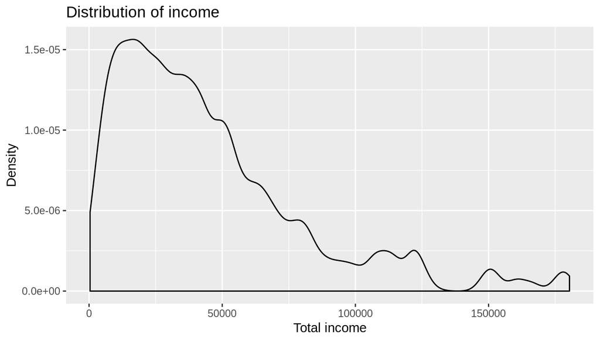

```r
g <- ggplot(gss_di_complete, aes(coninc))
g + geom_density() + labs(title = "Distribution of income") + labs(x = "Total income", y = "Density")
```

```r
conic_sd <- sd(gss_di_complete$coninc)
mean <- mean(gss_di_complete$coninc)
gss_q1 <- subset(gss_di_complete, (coninc < (mean + 3*conic_sd)) &( coninc > (mean-3*conic_sd)))

summary(gss_q1)
```

```
##             degree          coninc
##  Lt High School:10241   Min.   :   383
##  High School   :26096   1st Qu.: 18442
##  Junior College: 2744   Median : 35471
##  Bachelor      : 6992   Mean   : 42172
##  Graduate      : 3251   3rd Qu.: 57243
##                         Max.   :151053
```

```r
prop.table(summary(gss_q1$degree))
```

```
## Lt High School    High School Junior College       Bachelor       Graduate
##     0.20762712     0.52907307     0.05563215     0.14175655     0.06591112
```

```r
prop.table(summary(gss_q1$coninc))
```

```
##     Min.  1st Qu.   Median     Mean  3rd Qu.     Max.
## 0.001257 0.060512 0.116388 0.138377 0.187827 0.495639
```

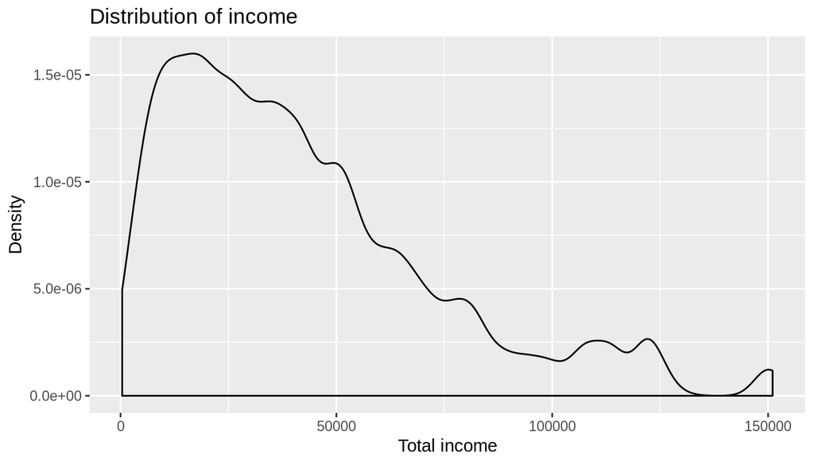

```r
g2 <- ggplot(gss_q1, aes(coninc))
g2 + geom_density() + labs(title = "Distribution of income") + labs(x = "Total income", y = "Density")
```

A majority of the US population has an education level of high school and below (~73%). Approximately 6% attain a Junior College, while about 21% hold a bachelor or higher degreee.

The median income is $35471, with a mean of $42172, and range of $383 - $151053

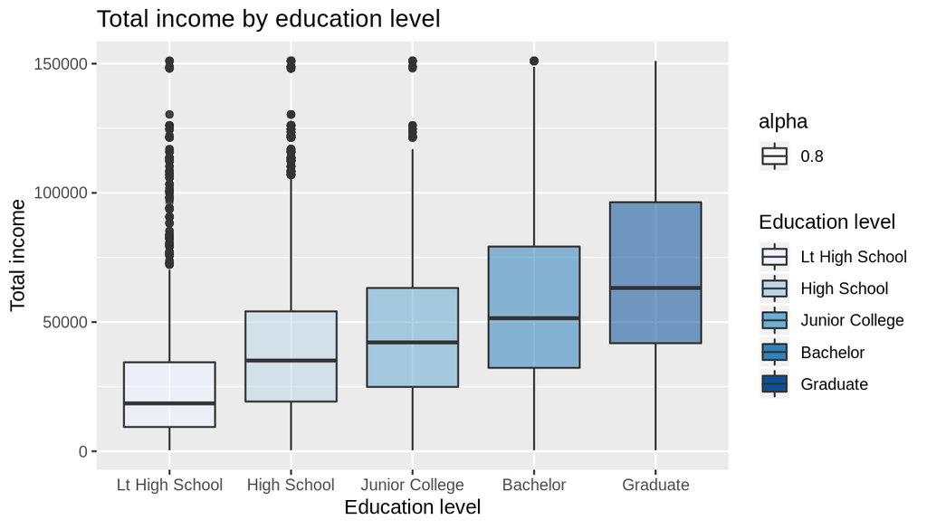

```r
ggplot(gss_q1, aes(factor(gss_q1$degree), gss_q1$coninc, fill = degree, alpha = 0.8)) +
  geom_boxplot() +
  ggtitle('Total income by education level') +
  xlab('Education level') + ylab('Total income') +
  scale_fill_brewer(name = "Education level")
```

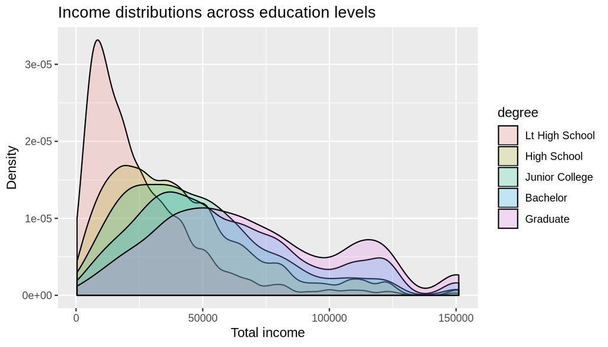

```r
g3 <- ggplot(gss_q1, aes(coninc, fill = degree))
g3 + geom_density (alpha = 0.2) + labs(title = "Income distributions across education levels") + labs(x = "Total income", y = "Density")
```

As shown The box plots suggest a significant and positive relationship between higher education and income, There are also a few outliner with the lower levels of education. This are certainly valid case, if we consider school dropouts as Steve Jobs (never finished college) or Bill Gates (never finished University). This also strongly indicated by the overlap plot where lower education have more density at the lower income and viceversa. * * *

## Part 4: Inference

We need to compare multiple means so we need to use ANOVA method. **H0:** u1 = u2 = u3 = u4 = u5, The mean income is the same across all levels of education. **HA** At least one pair of mean incomes are different from each other.

**Conditions:**

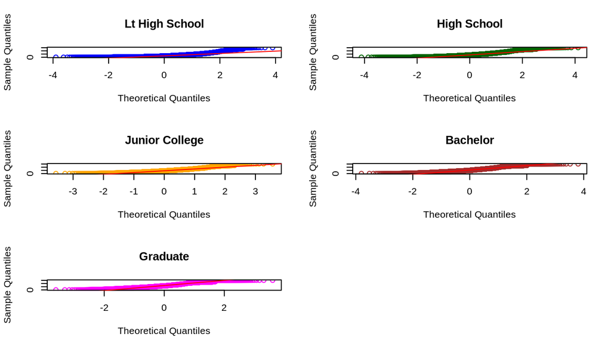

```r
# plot each group distiribution
par(mfrow = c(3,2))
qqnorm(gss_q1$coninc[gss_q1$degree == "Lt High School"], main = "Lt High School", col = 'blue')
qqline(gss_q1$coninc[gss_q1$degree == "Lt High School"], col = 'red')
qqnorm(gss_q1$coninc[gss_q1$degree == "High School"], main = "High School", col = 'darkgreen')
qqline(gss_q1$coninc[gss_q1$degree == "High School"], col = 'red')
qqnorm(gss_q1$coninc[gss_q1$degree == "Junior College"], main = "Junior College", col = 'orange')
qqline(gss_q1$coninc[gss_q1$degree == "Junior College"], col = 'red')
qqnorm(gss_q1$coninc[gss_q1$degree == "Bachelor"], main = "Bachelor", col = 'brown')
qqline(gss_q1$coninc[gss_q1$degree == "Bachelor"], col = 'red')
qqnorm(gss_q1$coninc[gss_q1$degree == "Graduate"], main = "Graduate", col = 'magenta')
qqline(gss_q1$coninc[gss_q1$degree == "Graduate"], col = 'red')
```

1. Independence:
- within groups: exist as it’s randomly sampled and n < 10% of the population for each group
- between groups: exist
2. Approximate Normality: exist, the normal probability plots for each education group show that the data is right skewed and deviates from normality, this is mitigated by the large sample sizes for each education group.
3. the previous box plots of income across education levels show roughly equal variance for the High School, Junior College, and Bachelor groups, while the Less than High School group has lower variance and the Graduate group has higher variance.

```r
# doing anova for the gss_q1 data
inference(y = coninc, x = degree, data = gss_q1, statistic = "mean", type = "ht", null = 0, alternative = "greater", method = "theoretical")
```

```
## Response variable: numerical
## Explanatory variable: categorical (5 levels)
## n_Lt High School = 10241, y_bar_Lt High School = 25053.8649, s_Lt High School = 22215.7819
## n_High School = 26096, y_bar_High School = 40638.5548, s_High School = 28443.758
## n_Junior College = 2744, y_bar_Junior College = 47445.5255, s_Junior College = 29915.1274
## n_Bachelor = 6992, y_bar_Bachelor = 58266.542, s_Bachelor = 34237.1169
## n_Graduate = 3251, y_bar_Graduate = 69343.877, s_Graduate = 36251.4672
##
## ANOVA:
##              df           Sum_Sq          Mean_Sq         F  p_value
## degree        4 7350016689551.55 1837504172387.89 2205.6868 < 0.0001
## Residuals 49319 41086462492455.2   833075741.4476
## Total     49323 48436479182006.8
##
## Pairwise tests - t tests with pooled SD:
## # A tibble: 10 x 3
##    group1         group2           p.value
##  * <chr>          <chr>              <dbl>
##  1 High School    Lt High School 0.
##  2 Junior College Lt High School 1.55e-281
##  3 Bachelor       Lt High School 0.
##  4 Graduate       Lt High School 0.
##  5 Junior College High School    7.65e- 32
##  6 Bachelor       High School    0.
##  7 Graduate       High School    0.
##  8 Bachelor       Junior College 5.04e- 62
##  9 Graduate       Junior College 1.09e-186
## 10 Graduate       Bachelor       7.94e- 73
```

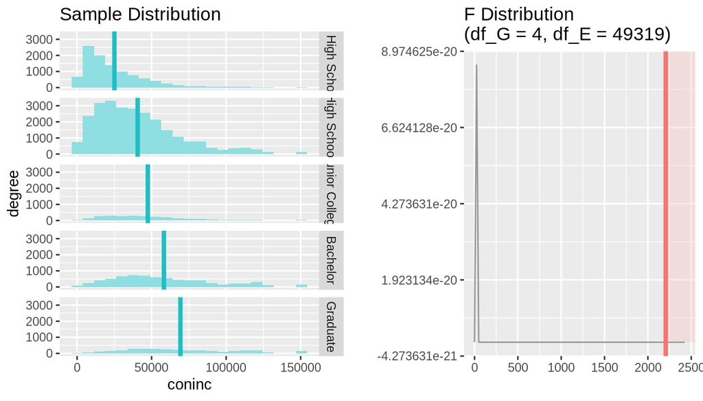

The F - Distribution with an amount of 2205 and a degree of freedom of 4 is relatively larger. Therefore the p-value will be rather small. Since the p-value is small (less than alpha < 0.0001 < 0.05)- 5% significance level, we reject H0 in favour of the alternative hypothesis HA. The data provides convincing evidence that at least one pair of population means are different from each other.